# 624 HW 5

### part d

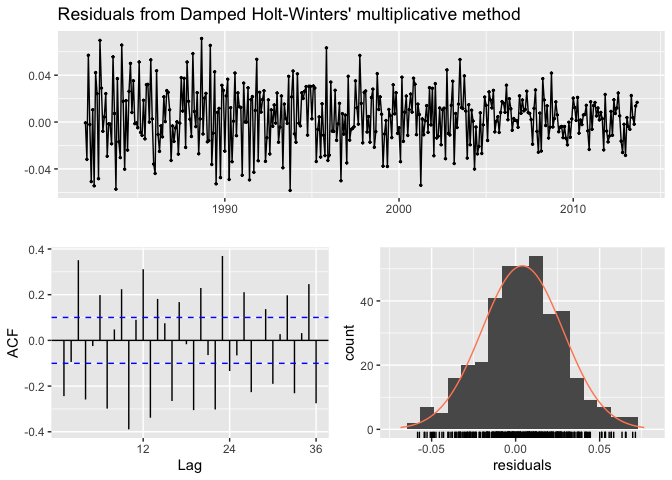

```
##
##  Ljung-Box test
##
## data:  Residuals from Damped Holt-Winters' multiplicative method
## Q* = 532.71, df = 7, p-value < 2.2e-16
##
## Model df: 17.   Total lags used: 24
```

```r
checkresiduals(fit_2)
```

This is a mixed bag of results on the residuals. The residuals have mean of zero and appear to be normally distributed. However, the ACF plot shows alternating correlations and the scatter plot does not have constant variance. Additionally, we have significant finding in the Ljung-Box test suggesting that the residuals are distinguishable from white noise. So we have a model that is not very biased, but also is not capturing all the forecastable information. This model could be improved.

### part e

```r
fit_3 <- hw(retail_train,seasonal="multiplicative",
            damped = TRUE)
fit_snaive <- snaive(retail_train)

paste("Holt's damped RMSE",
round(accuracy(fit_3, retail_test),3)[2],
"Seasonal Naive",
round(accuracy(fit_snaive, retail_test),3)[2])
```

```
## [1] "Holt's damped RMSE 90.299 Seasonal Naive 133.875"
```

# Question HA 7.9

For the same retail data, try an STL decomposition applied to the Box-Cox transformed series, followed by ETS on the seasonally adjusted data. How does that compare with your best previous forecasts on the test set?

## Answer

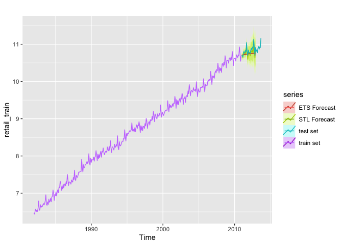

```r
lambda<- BoxCox.lambda(myts)
bc_retail<- BoxCox(myts, lambda)
retail_train <- window(bc_retail,end=c(2010,12))
retail_test <- window(bc_retail,start=2011)

fit_stl= stlf(retail_train,robust = TRUE, lambda = lambda)
fit_ets = ets(seasadj(decompose(retail_train, "multiplicative")),
              model = "ZZZ",
              lambda = lambda)

autoplot(retail_train, series = "train set") +
  autolayer(forecast(fit_stl, h = 24, PI=FALSE), series = "STL Forecast") +
  autolayer(forecast(fit_ets, h = 24, PI=FALSE), series = "ETS Forecast") +
  autolayer(retail_test, series = "test set")
```

```r
paste('STL Method RMSE',
round(accuracy(fit_stl, retail_test)[2],3),
'ETS Method',
round(fit_ets$mse^(0.5),3))
```

```
## [1] "STL Method RMSE 0.053 ETS Method 0.006"
```